# Health Insurance Marketplace Dataset Analysis

# Introduction

Analysis of the health insurance marketplace dataset from the U.S.The dataset consists of health insurance and dental plans offered through healthcare.gov between 2014 and 2016. It encompasses rates for smokers and non-smokers, separately listed for each age group, benefits included in the plans, states in which the plans were offered, and other information. The dataset does not contain any information on actual purchases. This notebook shows visulization of the dataset.

# Goal for this Application:

#### Install Required Libraries

```python
!pip install plotly
!pip install seaborn
```

```python
import pandas as pd
import csv as csv
import warnings
import matplotlib.pyplot as plt
import seaborn as sns
import numpy as np
import plotly.plotly as py
from plotly.offline import download_plotlyjs, init_notebook_mode, plot, iplot
import matplotlib
import plotly.graph_objs as go
from pylab import rcParams
from plotly.graph_objs import *
import plotly
from sklearn.decomposition import PCA
import matplotlib.pyplot as plt
from sklearn.preprocessing import scale
from plotly.offline import download_plotlyjs, init_notebook_mode, iplot
from plotly.offline.offline import _plot_html
init_notebook_mode(connected=True)
sns.set(style="ticks")
%matplotlib inline
plt.style.use('ggplot')
rcParams['figure.figsize'] = 15, 10
rcParams['font.size'] = 20
rcParams['axes.facecolor'] = 'white'
warnings.filterwarnings('ignore')
```

# Load Data from Object Storage

```python
from io import StringIO
import requests
import json
import pandas as pd

# @hidden_cell
# This function accesses a file in your Object Storage. The definition contains your credentials.
# You might want to remove those credentials before you share your notebook.
def get_object_storage_file_with_credentials_2b828cf4900f402fbf48658e734e24eb(container, filename):
    """This functions returns a StringIO object containing
    the file content from Bluemix Object Storage."""

    url1 = ''.join(['https://identity.open.softlayer.com', '/v3/auth/tokens'])
    data = {'auth': {'identity': {'methods': ['password'],
            'password': {'user': {'name': 'member_670d482c9ca078094c0452dd1ee37bad46637e26','domain': {'id': '7379ce49c7b448f0842f8de5825740e1'},
            'password': 'HhxL2if&8.SO*a)~'}}}}}
    headers1 = {'Content-Type': 'application/json'}
    resp1 = requests.post(url=url1, data=json.dumps(data), headers=headers1)
    resp1_body = resp1.json()
    for e1 in resp1_body['token']['catalog']:
        if(e1['type']=='object-store'):
            for e2 in e1['endpoints']:
                        if(e2['interface']=='public'and e2['region']=='dallas'):
                            url2 = ''.join([e2['url'],'/', container, '/', filename])
    s_subject_token = resp1.headers['x-subject-token']
    headers2 = {'X-Auth-Token': s_subject_token, 'accept': 'application/json'}
    resp2 = requests.get(url=url2, headers=headers2)
    return StringIO(resp2.text)

rate_raw = pd.read_csv(get_object_storage_file_with_credentials_2b828cf4900f402fbf48658e734e24eb('Test', 'Rate.csv'))
rate_raw.head()
```

|  | BusinessYear | StateCode | IssuerId | SourceName | VersionNum | ImportDate | IssuerId2 | FederalTIN | RateEffectiveDate | RateExpirationDate | ... | IndividualRate | IndividualTobaccoRate | Couple | PrimarySubscriberAndOneDependent | PrimarySubscriberAndTwoDependents | PrimarySubscriberAndThreeOrMoreDependents | CoupleAndOneDependent | CoupleAndTwoDependents | CoupleAndThreeOrMoreDependents | RowNumber |
| --- | --- | --- | --- | --- | --- | --- | --- | --- | --- | --- | --- | --- | --- | --- | --- | --- | --- | --- | --- | --- | --- |
| 0 | 2014 | AK | 21989 | HIOS | 6 | 2014-03-19 07:06:49 | 21989 | 93-0438772 | 2014-01-01 | 2014-12-31 | ... | 29.00 | NaN | NaN | NaN | NaN | NaN | NaN | NaN | NaN | 14 |
| 1 | 2014 | AK | 21989 | HIOS | 6 | 2014-03-19 07:06:49 | 21989 | 93-0438772 | 2014-01-01 | 2014-12-31 | ... | 36.95 | NaN | 73.9 | 107.61 | 107.61 | 107.61 | 144.56 | 144.56 | 144.56 | 14 |
| 2 | 2014 | AK | 21989 | HIOS | 6 | 2014-03-19 07:06:49 | 21989 | 93-0438772 | 2014-01-01 | 2014-12-31 | ... | 36.95 | NaN | 73.9 | 107.61 | 107.61 | 107.61 | 144.56 | 144.56 | 144.56 | 15 |
| 3 | 2014 | AK | 21989 | HIOS | 6 | 2014-03-19 07:06:49 | 21989 | 93-0438772 | 2014-01-01 | 2014-12-31 | ... | 32.00 | NaN | NaN | NaN | NaN | NaN | NaN | NaN | NaN | 15 |
| 4 | 2014 | AK | 21989 | HIOS | 6 | 2014-03-19 07:06:49 | 21989 | 93-0438772 | 2014-01-01 | 2014-12-31 | ... | 32.00 | NaN | NaN | NaN | NaN | NaN | NaN | NaN | NaN | 16 |

5 rows × 24 columns

```python
planattribute_raw = pd.read_csv(get_object_storage_file_with_credentials_2b828cf4900f402fbf48658e734e24eb('Test', 'PlanAttributes.csv'))
planattribute_raw.head()
```

|  | AVCalculatorOutputNumber | BeginPrimaryCareCostSharingAfterNumberOfVisits | BeginPrimaryCareDeductibleCoinsuranceAfterNumberOfCopays | BenefitPackageId | BusinessYear | CSRVariationType | ChildOnlyOffering | ChildOnlyPlanId | CompositeRatingOffered | DEHBCombInnOonFamilyMOOP | ... | TEHBOutOfNetFamilyMOOP | TEHBOutOfNetFamilyPerGroupMOOP | TEHBOutOfNetFamilyPerPersonMOOP | TEHBOutOfNetIndividualMOOP | TIN | URLForEnrollmentPayment | URLForSummaryofBenefitsCoverage | UniquePlanDesign | VersionNum | WellnessProgramOffered |
| --- | --- | --- | --- | --- | --- | --- | --- | --- | --- | --- | --- | --- | --- | --- | --- | --- | --- | --- | --- | --- | --- |
| 0 | NaN | 0 | 0 | 1 | 2014 | Standard Low Off Exchange Plan | Allows Adult and Child-Only | NaN | NaN | NaN | ... | NaN | NaN | NaN | NaN | 93-0438772 | https://www.modahealth.com/employers/enroll.shtml | https://www.modahealth.com/producers/grp/den.s... | NaN | 6 | NaN |
| 1 | NaN | 0 | 0 | 1 | 2014 | Standard Low On Exchange Plan | Allows Adult and Child-Only | NaN | NaN | NaN | ... | NaN | NaN | NaN | NaN | 93-0438772 | https://www.modahealth.com/employers/enroll.shtml | https://www.modahealth.com/producers/grp/den.s... | NaN | 6 | NaN |
| 2 | NaN | 0 | 0 | 1 | 2014 | Standard High Off Exchange Plan | Allows Adult and Child-Only | NaN | NaN | NaN | ... | NaN | NaN | NaN | NaN | 93-0438772 | https://www.modahealth.com/employers/enroll.shtml | https://www.modahealth.com/producers/grp/den.s... | NaN | 6 | NaN |
| 3 | NaN | 0 | 0 | 1 | 2014 | Standard Low Off Exchange Plan | Allows Adult and Child-Only | NaN | NaN | NaN | ... | NaN | NaN | NaN | NaN | 93-0438772 | https://www.modahealth.com/mymoda/ | https://www.modahealth.com/pdfs/plans/individu... | NaN | 6 | NaN |
| 4 | NaN | 0 | 0 | 1 | 2014 | Standard Low On Exchange Plan | Allows Adult and Child-Only | NaN | NaN | NaN | ... | NaN | NaN | NaN | NaN | 93-0438772 | https://www.modahealth.com/mymoda/ | https://www.modahealth.com/pdfs/plans/individu... | NaN | 6 | NaN |

5 rows × 176 columns

# Data Preprocessing

```python
rate_data=rate_raw[['BusinessYear','IssuerId','ImportDate','PlanId','Age','IndividualRate','Couple','CoupleAndOneDependent','CoupleAndTwoDependents','CoupleAndThreeOrMoreDependents','StateCode','Tobacco']]
rate_data.head(3)
```

|  | BusinessYear | IssuerId | ImportDate | PlanId | Age | IndividualRate | Couple | CoupleAndOneDependent | CoupleAndTwoDependents | CoupleAndThreeOrMoreDependents | StateCode | Tobacco |
| --- | --- | --- | --- | --- | --- | --- | --- | --- | --- | --- | --- | --- |
| 0 | 2014 | 21989 | 2014-03-19 07:06:49 | 21989AK0010001 | 0-20 | 29.00 | NaN | NaN | NaN | NaN | AK | No Preference |
| 1 | 2014 | 21989 | 2014-03-19 07:06:49 | 21989AK0020001 | Family Option | 36.95 | 73.9 | 144.56 | 144.56 | 144.56 | AK | No Preference |
| 2 | 2014 | 21989 | 2014-03-19 07:06:49 | 21989AK0020001 | Family Option | 36.95 | 73.9 | 144.56 | 144.56 | 144.56 | AK | No Preference |

First we clear out the weird data (with rates over 9,000) because usauaaly rates values for insuerance are less then 1000.

```python
rate_data[rate_data.IndividualRate>9000].IndividualRate.unique() # weird data
```

```
array([ 999999.  ,    9999.  ,    9999.99])
```

```python
rate_data = rate_data[rate_data.IndividualRate <9000]
```

While this line of code removes the NaN values from every remaining column / feature:

```python
rate_df = rate_data.dropna()
```

Convert date into pabdas date to draw map.

```python
rate_df['ImportDate']=rate_df['ImportDate'].apply(pd.to_datetime)
```

```python
rate_df.head()
```

|  | BusinessYear | IssuerId | ImportDate | PlanId | Age | IndividualRate | Couple | CoupleAndOneDependent | CoupleAndTwoDependents | CoupleAndThreeOrMoreDependents | StateCode | Tobacco |
| --- | --- | --- | --- | --- | --- | --- | --- | --- | --- | --- | --- | --- |
| 1 | 2014 | 21989 | 2014-03-19 07:06:49 | 21989AK0020001 | Family Option | 36.95 | 73.9 | 144.56 | 144.56 | 144.56 | AK | No Preference |
| 2 | 2014 | 21989 | 2014-03-19 07:06:49 | 21989AK0020001 | Family Option | 36.95 | 73.9 | 144.56 | 144.56 | 144.56 | AK | No Preference |
| 5 | 2014 | 21989 | 2014-03-19 07:06:49 | 21989AK0020001 | Family Option | 36.95 | 73.9 | 144.56 | 144.56 | 144.56 | AK | No Preference |
| 6 | 2014 | 21989 | 2014-03-19 07:06:49 | 21989AK0020002 | Family Option | 32.45 | 64.9 | 126.95 | 126.95 | 126.95 | AK | No Preference |
| 9 | 2014 | 21989 | 2014-03-19 07:06:49 | 21989AK0020002 | Family Option | 32.45 | 64.9 | 126.95 | 126.95 | 126.95 | AK | No Preference |

Now lets clean also Plan Attributes file.

Drop NAN rows from plan attribute data file.

```python
plan_data=planattribute_raw[['BusinessYear','StateCode','IssuerId','ImportDate','PlanId','MetalLevel',
                                        'TEHBInnTier1FamilyMOOP','TEHBInnTier1IndividualMOOP']]
plan_data.head(3)
```

|  | BusinessYear | StateCode | IssuerId | ImportDate | PlanId | MetalLevel | TEHBInnTier1FamilyMOOP | TEHBInnTier1IndividualMOOP |
| --- | --- | --- | --- | --- | --- | --- | --- | --- |
| 0 | 2014 | AK | 21989 | 2014-03-19 07:06:49 | 21989AK0020002-00 | Low | NaN | NaN |
| 1 | 2014 | AK | 21989 | 2014-03-19 07:06:49 | 21989AK0020002-01 | Low | NaN | NaN |
| 2 | 2014 | AK | 21989 | 2014-03-19 07:06:49 | 21989AK0020001-00 | High | NaN | NaN |

```python
plan_df = plan_data.dropna()
```

We are applying group by clause to get number of plans for each state.

```python
p = plan_df.groupby(["StateCode"], as_index=False)['PlanId'].count()
p = p.rename(columns={'PlanId': 'TotalPlans'})
state_df=p[["StateCode","TotalPlans"]]
```

```python
state_df.head()
```

|  | StateCode | TotalPlans |
| --- | --- | --- |
| 0 | AK | 412 |
| 1 | AL | 238 |
| 2 | AR | 638 |
| 3 | AZ | 2328 |
| 4 | DE | 234 |

Again Group by the Plan attribute file to get Types of Insurance Plans.

```python
df_plan1=plan_df.groupby(['MetalLevel'], as_index=False)['PlanId'].count()
```

Convert Import date to pandas date time.

```python
plan_data['ImportDate']=plan_data['ImportDate'].apply(pd.to_datetime)
```

Lets clean rate file for PCA to emphasize variation and bring out strong patterns in a dataset.

```python
data=rate_raw[['BusinessYear','VersionNum','Age','IndividualTobaccoRate','IndividualRate',
                    'Couple','PrimarySubscriberAndOneDependent','PrimarySubscriberAndTwoDependents','PrimarySubscriberAndThreeOrMoreDependents','CoupleAndOneDependent','CoupleAndTwoDependents','CoupleAndThreeOrMoreDependents','RowNumber']]
data.head(3)
```

|  | BusinessYear | VersionNum | Age | IndividualTobaccoRate | IndividualRate | Couple | PrimarySubscriberAndOneDependent | PrimarySubscriberAndTwoDependents | PrimarySubscriberAndThreeOrMoreDependents | CoupleAndOneDependent | CoupleAndTwoDependents | CoupleAndThreeOrMoreDependents | RowNumber |
| --- | --- | --- | --- | --- | --- | --- | --- | --- | --- | --- | --- | --- | --- |
| 0 | 2014 | 6 | 0-20 | NaN | 29.00 | NaN | NaN | NaN | NaN | NaN | NaN | NaN | 14 |
| 1 | 2014 | 6 | Family Option | NaN | 36.95 | 73.9 | 107.61 | 107.61 | 107.61 | 144.56 | 144.56 | 144.56 | 14 |
| 2 | 2014 | 6 | Family Option | NaN | 36.95 | 73.9 | 107.61 | 107.61 | 107.61 | 144.56 | 144.56 | 144.56 | 15 |

convert our dataset into numpy arrays

```python
X=data.values
```

# Visulization

#### Register States in Health Insurance Market Place

```python
for col in state_df.columns:
    state_df[col] = state_df[col].astype(str)
scl = [[0.0, 'rgb(242,240,247)'],[0.2, 'rgb(218,218,235)'],[0.4, 'rgb(188,189,220)'],\
            [0.6, 'rgb(158,154,200)'],[0.8, 'rgb(117,107,177)'],[1.0, 'rgb(84,39,143)']]

state_df['text'] = state_df['StateCode'] + '<br>' +'TotalPlans '+state_df['TotalPlans']
data = [ dict(
        type='choropleth',
        colorscale = scl,
        autocolorscale = False,
        locations = state_df['StateCode'],
        z = state_df['TotalPlans'].astype(float),
        locationmode = 'USA-states',
        text = state_df['text'],
        marker = dict(
            line = dict (
                color = 'rgb(255,255,255)',
                width = 2
            )
        ),
        colorbar = dict(
            title = "Millions USD"
        )
    ) ]

layout = dict(
        title = 'Plan by States',
        geo = dict(
            scope='usa',
            projection=dict( type='albers usa' ),
            showlakes = True,
            lakecolor = 'rgb(255, 255, 255)',
        ),
    )

fig = dict(data=data, layout=layout)
plotly.offline.iplot(fig)
```

[interactive chart not shown]

#### Individual Rates By State

```python
rate_box=rate_df.groupby(['StateCode'],as_index=False)['IndividualRate'].count()
rate_box['IndividualRate']=rate_box['IndividualRate'].astype(int)
rate_box.head()
```

|  | StateCode | IndividualRate |
| --- | --- | --- |
| 0 | AK | 186 |
| 1 | AL | 936 |
| 2 | AR | 196 |
| 3 | AZ | 938 |
| 4 | DE | 12 |

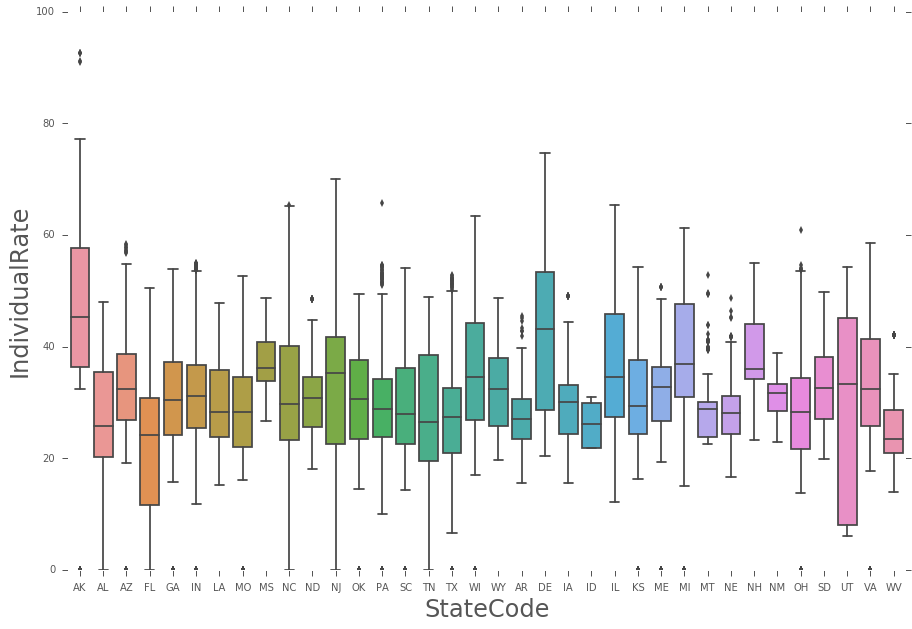

```python
sns.boxplot(rate_df['StateCode'],rate_df['IndividualRate'])
```

#### Insurance PlanType

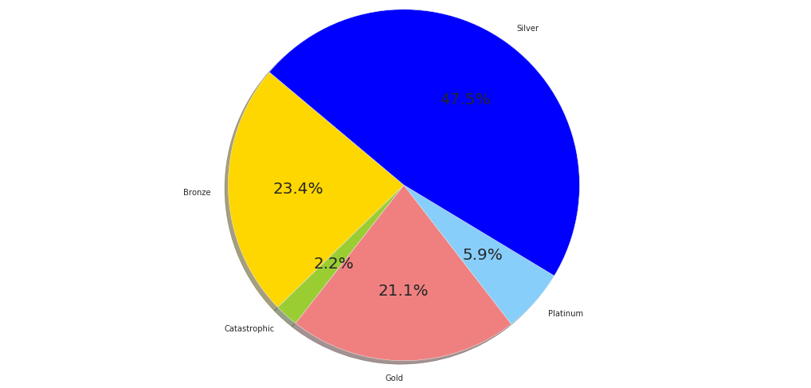

```python
labels = df_plan1['MetalLevel']
sizes = df_plan1['PlanId']
plt.figure(figsize=(18, 8))
colors = ['gold', 'yellowgreen', 'lightcoral', 'lightskyblue','blue']
plt.pie(sizes, labels=labels, colors=colors,
        autopct='%1.1f%%', shadow=True, startangle=140)

plt.axis('equal')
plt.show()
```

# PCA (Principle Component Analysis)

Here we will use a pca of analysis which involves finding the linear combination of a set of variables that has maximum variance and removing its effect, repeating this successively.

First of all we will delete all column from rate dataframe that contain on categorical variable because we will find the linear combination between rates.

```python
rate_df.loc[rate_df.Tobacco == 'No Preference', 'Tobacco'] = 0
rate_df.drop(['StateCode','Age','PlanId','ImportDate'], axis = 1, inplace = True, errors = 'ignore')

rate_df.head()
```

|  | BusinessYear | IssuerId | IndividualRate | Couple | CoupleAndOneDependent | CoupleAndTwoDependents | CoupleAndThreeOrMoreDependents | Tobacco |
| --- | --- | --- | --- | --- | --- | --- | --- | --- |
| 1 | 2014 | 21989 | 36.95 | 73.9 | 144.56 | 144.56 | 144.56 | 0 |
| 2 | 2014 | 21989 | 36.95 | 73.9 | 144.56 | 144.56 | 144.56 | 0 |
| 5 | 2014 | 21989 | 36.95 | 73.9 | 144.56 | 144.56 | 144.56 | 0 |
| 6 | 2014 | 21989 | 32.45 | 64.9 | 126.95 | 126.95 | 126.95 | 0 |
| 9 | 2014 | 21989 | 32.45 | 64.9 | 126.95 | 126.95 | 126.95 | 0 |

Lets take values of rates from dataframe.

```python
X=rate_df.values
```

Whether to standardize the data prior to a PCA on the covariance matrix depends on the measurement scales of the original features. Since PCA yields a feature subspace that maximizes the variance along the axes, it makes sense to standardize the data, especially, if it was measured on different scales.Let us continue with the transformation of the data onto unit scale (mean=0 and variance=1), which is a requirement for the optimal performance of many machine learning algorithms.

```python
from sklearn.preprocessing import StandardScaler
X_std = StandardScaler().fit_transform(X)
```

he classic approach to PCA is to perform the eigendecomposition on the covariance matrix ΣΣ, which is a d×dd×d matrix where each element represents the covariance between two features.  
The mean vector is a dd-dimensional vector where each value in this vector represents the sample mean of a feature column in the dataset.

```python
import numpy as np
mean_vec = np.mean(X_std, axis=0)
cov_mat = (X_std - mean_vec).T.dot((X_std - mean_vec)) / (X_std.shape[0]-1)
print('Covariance matrix \n%s' %cov_mat)
```

```
Covariance matrix
[[ 1.00002443 -0.05313557 -0.01902136 -0.05061529 -0.02607603 -0.0436123
  -0.06452629  0.        ]
 [-0.05313557  1.00002443 -0.05290966  0.00203258  0.01154799  0.01848674
   0.02464227  0.        ]
 [-0.01902136 -0.05290966  1.00002443  0.78903132  0.70761267  0.69135471
   0.64208897  0.        ]
 [-0.05061529  0.00203258  0.78903132  1.00002443  0.96818315  0.96755245
   0.92764829  0.        ]
 [-0.02607603  0.01154799  0.70761267  0.96818315  1.00002443  0.97293643
   0.9158371   0.        ]
 [-0.0436123   0.01848674  0.69135471  0.96755245  0.97293643  1.00002443
   0.98295936  0.        ]
 [-0.06452629  0.02464227  0.64208897  0.92764829  0.9158371   0.98295936
   1.00002443  0.        ]
 [ 0.          0.          0.          0.          0.          0.          0.
   0.        ]]
```

The eigenvectors and eigenvalues of a covariance (or correlation) matrix represent the “core” of a PCA: The eigenvectors (principal components) determine the directions of the new feature space, and the eigenvalues determine their magnitude. In other words, the eigenvalues explain the variance of the data along the new feature axes.

```python
cov_mat = np.cov(X_std.T)

eig_vals, eig_vecs = np.linalg.eig(cov_mat)

print('Eigenvectors \n%s' %eig_vecs)
print('\nEigenvalues \n%s' %eig_vals)
```

```
Eigenvectors
[[ -2.68433475e-02   6.79432632e-01  -7.32284902e-01  -2.39847181e-02
   -2.38639079e-02  -1.56578840e-02   4.43098341e-03   0.00000000e+00]
 [  2.14459714e-03  -7.27035581e-01  -6.78164490e-01   1.07269037e-01
    7.41931477e-04  -5.95517436e-04   1.91455073e-04   0.00000000e+00]
 [  3.79547225e-01   9.12904155e-02   4.35536349e-02   8.88576585e-01
   -1.66713589e-01   1.68283210e-01   5.66016967e-03   0.00000000e+00]
 [  4.68984401e-01   5.66669172e-03  -2.39592316e-03   7.37515777e-03
    2.57828865e-01  -8.44424031e-01   2.08259403e-02   0.00000000e+00]
 [  4.61207319e-01   8.26903507e-03  -3.29004778e-02  -1.63736443e-01
    6.51828223e-01   4.62456111e-01   3.47248731e-01   0.00000000e+00]
 [  4.66719981e-01  -1.19007041e-02  -2.58574951e-02  -2.50144460e-01
   -1.04878629e-01   2.04873181e-01  -8.15976363e-01   0.00000000e+00]
 [  4.52473910e-01  -3.48497715e-02  -1.40725204e-02  -3.30020412e-01
   -6.85041065e-01   5.04442108e-02   4.61644308e-01   0.00000000e+00]
 [  0.00000000e+00   0.00000000e+00   0.00000000e+00   0.00000000e+00
    0.00000000e+00   0.00000000e+00   0.00000000e+00   1.00000000e+00]]

Eigenvalues
[  4.45149008e+00   1.05766116e+00   9.47830065e-01   4.37210683e-01
   8.39264687e-02   2.14470062e-02   6.05518861e-04   0.00000000e+00]
```

However, the eigendecomposition of the covariance matrix (if the input data was standardized) yields the same results as a eigendecomposition on the correlation matrix, since the correlation matrix can be understood as the normalized covariance matrix.

The typical goal of a PCA is to reduce the dimensionality of the original feature space by projecting it onto a smaller subspace, where the eigenvectors will form the axes. However, the eigenvectors only define the directions of the new axis, since they have all the same unit length 1, which can confirmed by the following two lines of code:

```python
for ev in eig_vecs:
    np.testing.assert_array_almost_equal(1.0, np.linalg.norm(ev))
print('Everything ok!')
```

```
Everything ok!
```

In order to decide which eigenvector(s) can dropped without losing too much information for the construction of lower-dimensional subspace, we need to inspect the corresponding eigenvalues: The eigenvectors with the lowest eigenvalues bear the least information about the distribution of the data; those are the ones can be dropped. In order to do so, the common approach is to rank the eigenvalues from highest to lowest in order choose the top kk eigenvectors.

```python
# Make a list of (eigenvalue, eigenvector) tuples
eig_pairs = [(np.abs(eig_vals[i]), eig_vecs[:,i]) for i in range(len(eig_vals))]

# Sort the (eigenvalue, eigenvector) tuples from high to low
eig_pairs.sort(key=lambda x: x[0], reverse=True)

# Visually confirm that the list is correctly sorted by decreasing eigenvalues
print('Eigenvalues in descending order:')
for i in eig_pairs:
    print(i[0])
```

```
Eigenvalues in descending order:
4.4514900786
1.05766116175
0.94783006519
0.437210682668
0.0839264686561
0.021447006202
0.000605518861222
0.0
```

After sorting the eigenpairs, the next question is “how many principal components are we going to choose for our new feature subspace?” A useful measure is the so-called “explained variance,” which can be calculated from the eigenvalues. The explained variance tells us how much information (variance) can be attributed to each of the principal components.

```python
tot = sum(eig_vals)
var_exp = [(i / tot)*100 for i in sorted(eig_vals, reverse=True)]
cum_var_exp = np.cumsum(var_exp)
```

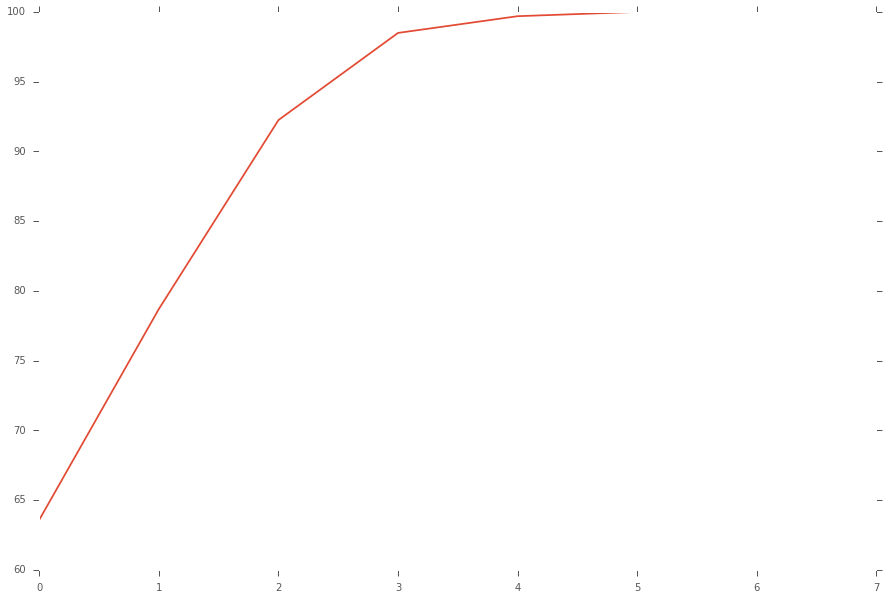

```python
plt.plot(cum_var_exp)
```

This shows that our first four principle components contains on 95% information.